# Visualization Demo

Matt Multach

2021-11-15

## Introduction

This document demonstrates the visualization of coefficient inclusion results from our 100-split model data. Graphical objects and manipulation also feature heavily, so we will discuss the many tools I used to present these visuals.

Due to the multiple tools used to visualize the data effectively, this demo will be a bit longer and more involved than most other demos.

I will not be interpreting the plots produced in this demo. This walkthrough is intended primarily to demonstrate this component of the overall combined model process being proposed and the tools necessary to make this component accomplish its goals. That way, newer users can understand the combination of tools that create the larger combined model without detracting from the full walkthrough that these components build towards.

## Preamble and Setup

### A note on formatting

This document makes use of **bolding**, *italics*, and “quotations” to help distinguish different types of items being referenced.

- **bolding** will be used when referencing a new term or concept for the first time. Subsequent references to each term/concept will *not* be bolded.
- *italics* will be used primarily for emphasis.
- ‘single quotations’ will be used to clarify specific arguments for a function, or specific parameters of a mathemtical/statistical formulation
- Inline references to code (functions, objects, specific commands, etc.) will use **`code_chunk_formatting`** in **`bolded blue font`**
- Inline references to packages will similarly use *`code_chunk_formatting`*, except in *`italicized red font`*
- References to other documents in this repository will use `code_chunk_formatting` in `un-italicized, un-bolded, green font`

Re: spacing and line breaks - I’m pretty heterogeneous in my application of line breaks and spacing, in a way that is idiosyncratic to my own code practice. The most important aspects of my spacing and line breaks are detailed below

I generally put spaces between code inputs I consider “sufficiently distinct”. This improves readability generally, but I find it particularly helpful for debugging. Note, however, that spaces are generally trivial in between distinct code inputs in R, although this is not universally the case. Multi-character code inputs, such as the pointer **`<-`** and most logical operators, *cannot* include spaces in between components of the code input. Note also that whitespace *is* meaningful in other programming languages, and so this convention should be considered with caution in your own practice.

Generally, I use line breaks to:

- Break up separate arguments for a single command/function or chain of operations
- To clearly distinguish between different closing parentheses, brackets, squigglies, etc., since RStudio will automatically tab each closing piece to match its opener.

### Packages

Let’s load the necessary packages. Links to more information about each packages and helpful guides (where applicable) can be found in `00B_Package_Descr_Refs`. Appropriate references for each package can be found in the “References” section at the end of this document.

```r
# This chunk loads the packages used in this workbook
library(xaringan)     # Allows active preview of report in RStudio
library(magrittr)     # Used for piping
library(purrr)        # Used for mapping functions efficiently
library(data.table)   # For more streamlined data structures
library(glmnet)       # For general lasso/elastic net functionality
library(hqreg)        # For LAD/Huber-loss regularization with SNCD algorithm
library(rlang)        # For parse_expr() to parse data name in k-fold subsetting functions
library(msaenet)      # For the multi-step adaptive elastic net
library(gridExtra)    # For displaying grids of objects
library(grid)         # For creating a title for multiplot grid
library(ggplot2)      # For generating and manipulation graphical objects
```

### Model Loading

Let’s load our 100-split model file with **`"Frequencies"`** data.table.

```r
models_freqs <- readRDS("/Users/Matt/Desktop/GitHub_Dissertation_Scripts/Robust_Lasso_ElasticNet/Datasets/models100_plus_freqs.RData")
```

## Visualization

Now we’re going to set up our visualizations. There are going to be three sets of plots:

- Plots of selection frequencies of all predictors by each adaptation
- Plots of $100\%$ and $0\%$ selection by each adaptation
- Plots of frequency of $100\%$ and $0\%$ selection of each predictor across adaptations

### Visualization Setup

I’m going to create a few practical tools/objects that will be used in our subsequent visualizations.

#### Custom Color Palette

The first thing I’m going to do is create a custom color palette that ensures that the colors are sufficiently distinct. This isn’t super necessary for the plots we’re generating, but it is an easy tool I picked up for more intricate plots used in my dissertation and is worth including for interested users. This command just creates a vector of strings that correspond with html color codes.

First, I’m going to make a palette of 11 distinct colors. These are the colors I used when visualizing 11 different lasso and elastic net adaptations in my dissertation. I found that these colors produced pretty meaningful distinctions, so we should be able to sample a practical color palette from these 11 for our purposes. We need two color palettes: one for each of 7 adaptations, and one for each of 8 potential predictors in our models.

```r
P11 <- c("#02AD24" , "#FF0000" , "#0000FF" , "#9A4D42" ,
         "#00FFBE" , "#FF00B6" , "#000033" , "#00FF00" ,
         "#FFD300" , "#009FFF" ,  "#783FC1")
```

```r
P7 <- sample(x = P11 , size = 7 , replace = FALSE)
```

```r
P8 <- sample(x = P11 , size = 8 , replace = FALSE)
```

#### Plot legend function

I’m also going to implement a function that stores a plot legend to an object for use with multi-plot displays. I can’t remember where I found the function and can’t relocate the original post, but I did *not* create this function myself! Should I ever run across this function again in the wild, I’ll update this section to give proper credit.

Update 10/23/2021: [Found it!](https://stackoverflow.com/questions/11883844/inserting-a-table-under-the-legend-in-a-ggplot2-histogram). See the top-rated response - the first one that appears below the asker’s post.

```r
g_legend<-function(a.gplot){
       tmp <- ggplot_gtable(ggplot_build(a.gplot))
       leg <- which(sapply(tmp$grobs , function(x) x$name) == "guide-box")
       legend <- tmp$grobs[[leg]]
       return(legend)
       }
```

### Visualization: All Predictors and Adaptations

#### Plot Objects

Now, I’m going to create 7 separate plots. The plots will present the selection frequencies of each potential predictor for each of the 7 lasso/elastic net adaptations included in the combined model.

As in 04B, when processing coefficient selection frequencies, I will not be #-commenting on each line to explain it. Instead, see below the chunk for a line-by-line walkthrough of the code.

```r
huberelnet.pl <- ggplot(data = models_freqs[["Frequencies"]][["By_Predictor"]][ , c("huberelnet" , "predictor") , ] ,
                     aes(x = predictor , y = huberelnet)) +
  geom_col(aes(fill = predictor)) +
  labs(title = "Adaptive Huber Elastic Net" ,
       y = "Frequency") +
  theme(legend.position = "none" ,
        plot.title = element_text(hjust = 0.5 ,
                                  size = 8) ,
        axis.title.x = element_text(size = 8) ,
        axis.title.y = element_text(size = 8)) +
  scale_fill_manual(values = P8)
```

Now we’re going to do the same for each of the 6 remaining adaptations.

```r
huberlasso.pl <- ggplot(data = models_freqs[["Frequencies"]][["By_Predictor"]][ , c("huberlasso" , "predictor") , ] ,
                     aes(x = predictor , y = huberlasso)) +
  geom_col(aes(fill = predictor)) +
  labs(title = "Adaptive Huber Lasso" ,
       y = "Frequency") +
  theme(legend.position = "none" ,
        plot.title = element_text(hjust = 0.5 ,
                                  size = 8) ,
        axis.title.x = element_text(size = 8) ,
        axis.title.y = element_text(size = 8)) +
  scale_fill_manual(values = P8)
```

```r
ladelnet.pl <- ggplot(data = models_freqs[["Frequencies"]][["By_Predictor"]][ , c("ladelnet" , "predictor") , ] ,
                     aes(x = predictor , y = ladelnet)) +
  geom_col(aes(fill = predictor)) +
  labs(title = "Adaptive LAD Elastic Net" ,
       y = "Frequency") +
  theme(legend.position = "none" ,
        plot.title = element_text(hjust = 0.5 ,
                                  size = 8) ,
        axis.title.x = element_text(size = 8) ,
        axis.title.y = element_text(size = 8)) +
  scale_fill_manual(values = P8)
```

```r
ladlasso.pl <- ggplot(data = models_freqs[["Frequencies"]][["By_Predictor"]][ , c("ladlasso" , "predictor") , ] ,
                     aes(x = predictor , y = ladlasso)) +
  geom_col(aes(fill = predictor)) +
  labs(title = "Adaptive LAD Lasso" ,
       y = "Frequency") +
  theme(legend.position = "none" ,
        plot.title = element_text(hjust = 0.5 ,
                                  size = 8) ,
        axis.title.x = element_text(size = 8) ,
        axis.title.y = element_text(size = 8)) +
  scale_fill_manual(values = P8)
```

```r
msak10.pl <- ggplot(data = models_freqs[["Frequencies"]][["By_Predictor"]][ , c("msak10" , "predictor") , ] ,
                     aes(x = predictor , y = msak10)) +
  geom_col(aes(fill = predictor)) +
  labs(title = "10-Step Adaptive Elastic Net" ,
       y = "Frequency") +
  theme(legend.position = "none" ,
        plot.title = element_text(hjust = 0.5 ,
                                  size = 8) ,
        axis.title.x = element_text(size = 8) ,
        axis.title.y = element_text(size = 8)) +
  scale_fill_manual(values = P8)
```

```r
msak3.pl <- ggplot(data = models_freqs[["Frequencies"]][["By_Predictor"]][ , c("msak3" , "predictor") , ] ,
                     aes(x = predictor , y = msak3)) +
  geom_col(aes(fill = predictor)) +
  labs(title = "3-Step Adaptive Elastic Net" ,
       y = "Frequency") +
  theme(legend.position = "none" ,
        plot.title = element_text(hjust = 0.5 ,
                                  size = 8) ,
        axis.title.x = element_text(size = 8) ,
        axis.title.y = element_text(size = 8)) +
  scale_fill_manual(values = P8)
```

```r
msak5.pl <- ggplot(data = models_freqs[["Frequencies"]][["By_Predictor"]][ , c("msak5" , "predictor") , ] ,
                     aes(x = predictor , y = msak5)) +
  geom_col(aes(fill = predictor)) +
  labs(title = "5-Step Adaptive Elastic Net" ,
       y = "Frequency") +
  theme(legend.position = "none" ,
        plot.title = element_text(hjust = 0.5 ,
                                  size = 8) ,
        axis.title.x = element_text(size = 8) ,
        axis.title.y = element_text(size = 8)) +
  scale_fill_manual(values = P8)
```

I’m also going to create a blank ggplot object to help with arranging our multi-plot display.

```r
blank.pl <- ggplot() +
  geom_blank() +
  theme_minimal()
```

#### Create Plot Legend

Let’s also create the legend for this multi-plot. Since all refer to the same predictors, we can just pull this from a single adaptation’s plot object. First, though, we need to create a plot object that includes a legend.

```r
msak5.l <- ggplot(data = models_freqs[["Frequencies"]][["By_Predictor"]][ , c("msak5" , "predictor") , ] ,
                     aes(x = predictor , y = msak5)) +
  geom_col(aes(fill = predictor)) +
  labs(title = "5-Step Adaptive Elastic Net" ,
       y = "Frequency") +
  theme(plot.title = element_text(hjust = 0.5 ,
                                  size = 8) ,
        axis.title.x = element_text(size = 8) ,
        axis.title.y = element_text(size = 8)) +
  scale_fill_manual(values = P8)
```

```r
plotA.legend <- g_legend(msak5.l)
```

#### Put Plot Objects Together

Lastly (for this plot), we’re going to create a grid arrangement of our plots so that they are all presented in a simultaneous object. A few explanations:

- **`arrangeGrob()`** and **`grid.arrange()`** take a set of grid objects (“Grobs”), specified as distinct arguments, along with an argument specifying either number of columns or number of rows (‘nrow’ here)
  - Note that it reads in the Grobs row-wise - so it will populate Row 1-Column 1, then R1C2, R1C3, move down to R2C1, etc.
- We’re using a second **`arrangeGrob()`** command for the legend, which will take up its own space in the overall plot grid
- We then specify that the collection of these two **`arrangeGrob()`** commands will take up 2 columns
- We specify the width of each of our two columns
  - Note that the number of widths specified needs to match the number of columns specified by ‘ncol’
- Finally, we’re adding a Grob at the top containing our title, which was created using **`textGrob()`** from the *`grid`* package

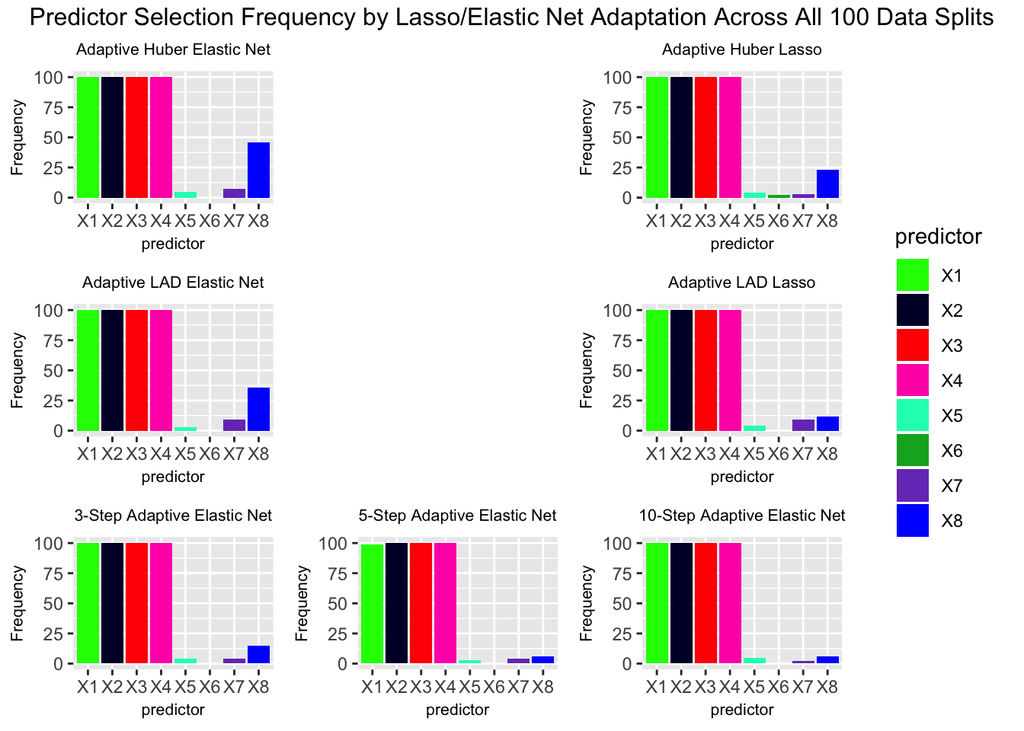

```r
plotA <- grid.arrange(arrangeGrob(huberelnet.pl , blank.pl , huberlasso.pl ,
                                  ladelnet.pl , blank.pl , ladlasso.pl ,
                                  msak3.pl , msak5.pl , msak10.pl ,
                                  nrow = 3) ,
                       arrangeGrob(plotA.legend) ,
                      ncol = 2 , widths = c(200 , 40) ,
                      top = textGrob("Predictor Selection Frequency by Lasso/Elastic Net Adaptation Across All 100 Data Splits"))
```

### Visualization: All/None Predictor Selection by Adaptation

#### Plot Objects

Now, I’m going to create 2 separate plots. One plot will display the number of predictors selected into $100\%$ of models by each of the 7 adaptations, while the second plot will display similar information for number of predictors selected into *no* models by adaptation. We can mostly just take our previous code and make slight changes, but the structure of creating these objects is largely the same.

Two noteworthy additions/changes were made, though. First, an additional visual layer was specified by **`coord_cartesian()`**, which explicitly controls the range of the plot display. I’m only specifying the limits of the range with respect to y, but a similar ‘xlim’ argument can be specified within **`coord_cartesian()`** as well.

I’ve also angled the axis ticks for the x-axis to facilitate a later plot. This is specified by the argument “axis.text.x” in the **`theme()`** layer. I’ve also vertically- and horizontally-justified these labels in the same argument to prevent collision with the plots themselves.

Notably, we only need two plots this time.

```r
adapt100.pl <- ggplot(data = models_freqs[["Frequencies"]][["By_Adaptation"]][ , c("all" , "method") , ] ,
                     aes(x = method , y = all)) +
  geom_col(aes(fill = method)) +
  labs(title = "100% Selection" ,
       y = "100% Selection (out of 7)" ,
       x = "Adaptation") +
  coord_cartesian(ylim = c(0 , 5)) +
  theme(legend.position = "none" ,
        plot.title = element_text(hjust = 0.5 ,
                                  size = 8) ,
        axis.text.x = element_text(hjust = 1 ,
                                   vjust = 1 ,
                                   angle = 45)) +
  scale_fill_manual(values = P7)
```

```r
adapt0.pl <- ggplot(data = models_freqs[["Frequencies"]][["By_Adaptation"]][ , c("none" , "method") , ] ,
                     aes(x = method , y = none)) +
  geom_col(aes(fill = method)) +
  labs(title = "0% Selection" ,
       y = "0% Selection (out of 8)" ,
       x = "Adaptation") +
  coord_cartesian(ylim = c(0 , 5)) +
  theme(legend.position = "none" ,
        plot.title = element_text(hjust = 0.5 ,
                                  size = 8) ,
        axis.text.x = element_text(hjust = 1 ,
                                   vjust = 1 ,
                                   angle = 45)) +
  scale_fill_manual(values = P7)
```

#### Create Plot Legend

Let’s also create the legend for this multi-plot after creating an analogous plot with the legend included.

```r
adapt100.l <- ggplot(data = models_freqs[["Frequencies"]][["By_Adaptation"]][ , c("all" , "method") , ] ,
                     aes(x = method , y = all)) +
  geom_col(aes(fill = method)) +
  labs(title = "100% Selection" ,
       y = "100% Selection (out of 8)" ,
       x = "Adaptation") +
  coord_cartesian(ylim = c(0 , 5)) +
  theme(plot.title = element_text(hjust = 0.5 ,
                                  size = 8) ,
        axis.text.x = element_text(angle = 45)) +
  scale_fill_manual(values = P7)
```

```r
plotB.legend <- g_legend(adapt100.l)
```

#### Put Plot Objects Together

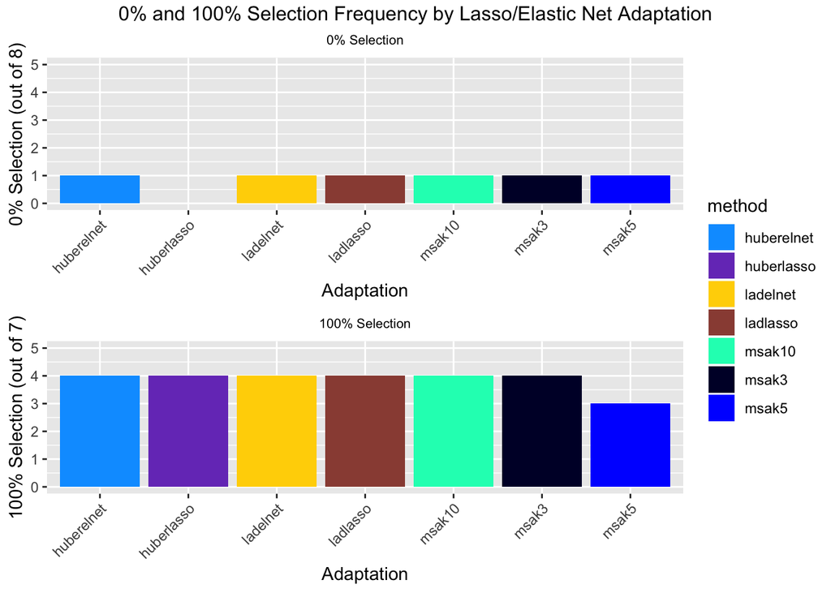

```r
plotB <- grid.arrange(arrangeGrob(adapt0.pl ,
                                  adapt100.pl ,
                                  nrow = 2) ,
                       arrangeGrob(plotB.legend) ,
                      ncol = 2 , widths = c(200 , 40) ,
                      top = textGrob("0% and 100% Selection Frequency by Lasso/Elastic Net Adaptation"))
```

### Visualization: All/None Predictor Selection by Predictor

#### Plot Objects

I’m going to create analogous plots to those in the previous subsection. This time, however, the plots look at the number of adaptations for which a given predictor was *always* or *never* selected across the 100 data splits.

```r
pred100.pl <- ggplot(data = models_freqs[["Frequencies"]][["By_Predictor"]][ , c("all" , "predictor") , ] ,
                     aes(x = predictor , y = all)) +
  geom_col(aes(fill = predictor)) +
  labs(title = "100% Selection" ,
       y = "100% Selection (out of 8 possible)" ,
       x = "Predictor") +
  coord_cartesian(ylim = c(0 , 5)) +
  theme(legend.position = "none" ,
        plot.title = element_text(hjust = 0.5 ,
                                  size = 8) ,
        axis.text.x = element_text(angle = 45)) +
  scale_fill_manual(values = P8)
```

```r
pred0.pl <- ggplot(data = models_freqs[["Frequencies"]][["By_Predictor"]][ , c("none" , "predictor") , ] ,
                     aes(x = predictor , y = none)) +
  geom_col(aes(fill = predictor)) +
  labs(title = "0% Selection" ,
       y = "0% Selection (out of 8 possible)" ,
       x = "Predictor") +
  coord_cartesian(ylim = c(0 , 5)) +
  theme(legend.position = "none" ,
        plot.title = element_text(hjust = 0.5 ,
                                  size = 8) ,
        axis.text.x = element_text(angle = 45)) +
  scale_fill_manual(values = P8)
```

#### Create Plot Legend

Let’s also create the legend for this multi-plot after creating an analogous plot with the legend included.

```r
pred100.l <- ggplot(data = models_freqs[["Frequencies"]][["By_Predictor"]][ , c("all" , "predictor") , ] ,
                     aes(x = predictor , y = all)) +
  geom_col(aes(fill = predictor)) +
  labs(title = "100% Selection" ,
       y = "100% Selection (out of 7)" ,
       x = "Predictor") +
  coord_cartesian(ylim = c(0 , 5)) +
  theme(plot.title = element_text(hjust = 0.5 ,
                                  size = 8)) +
  scale_fill_manual(values = P8)
```

```r
plotC.legend <- g_legend(pred100.l)
```

#### Put Plot Objects Together

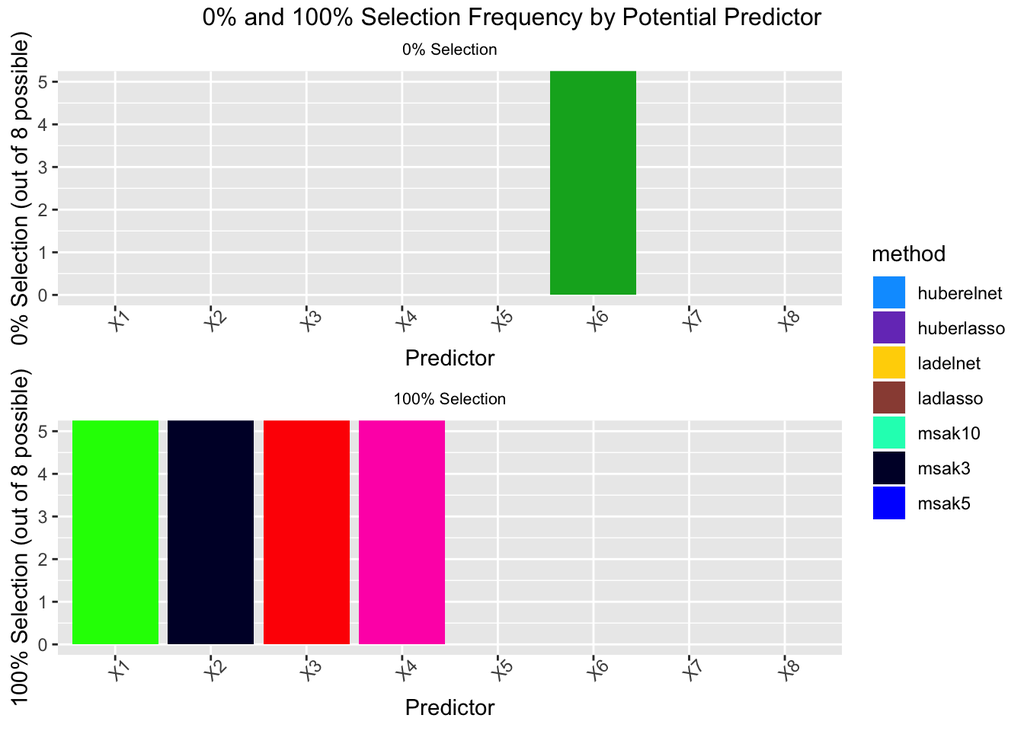

```r
plotC <- grid.arrange(arrangeGrob(pred0.pl ,
                                  pred100.pl ,
                                  nrow = 2) ,
                       arrangeGrob(plotB.legend) ,
                      ncol = 2 , widths = c(200 , 40) ,
                      top = textGrob("0% and 100% Selection Frequency by Potential Predictor"))
```

## One Last Visualization

I’m going to combine combine the elements of the last two plots into a single display to finalize this walkthrough and emphasize some of the visual display tools at our disposal in R.

First, though, I would like you to attempt this on your own. There is a hint below as to how I am going to accomplish this, although multiple formats could be used.

### Hint

extra space

extra space

lots of meaningless, extra space

bloop

bleep

blop

### Extra space so you don’t mistakenly see the answer if you’re trying to avoid it!

extra space

extra space

lots of meaningless, extra space

bloop

bleep

blop

#### Combined 100/0 Multiplot

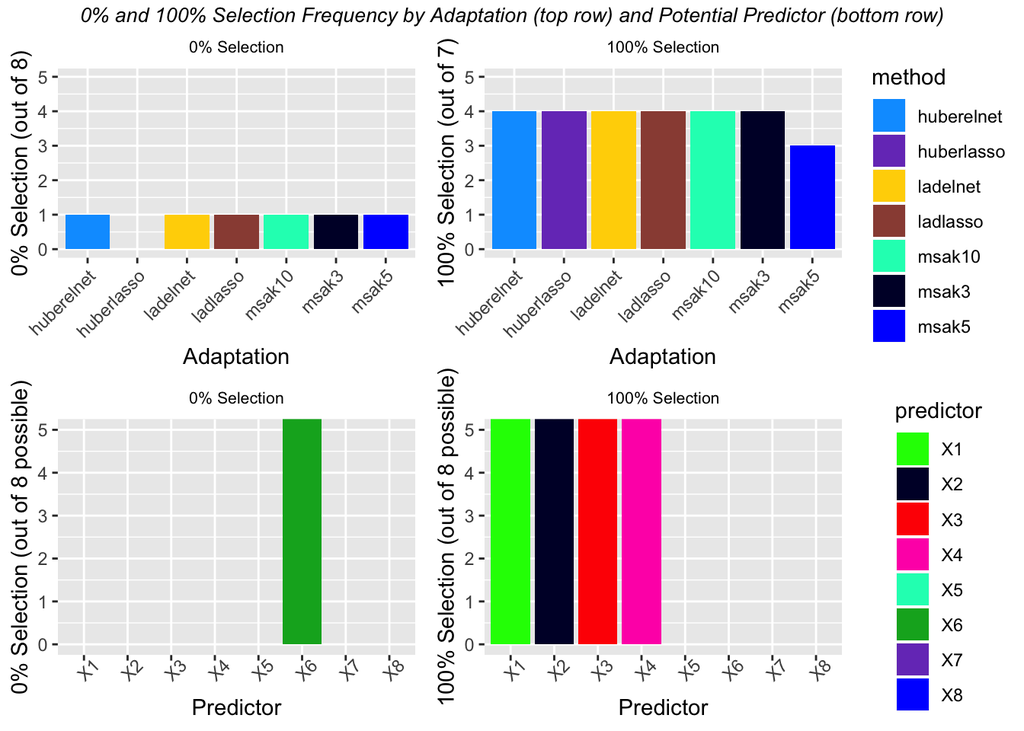

```r
plotD <- grid.arrange(arrangeGrob(adapt0.pl , adapt100.pl ,
                                  pred0.pl , pred100.pl ,
                                  nrow = 2) ,
                       arrangeGrob(plotB.legend ,
                                   plotC.legend ,
                                   nrow = 2) ,
                      ncol = 2 , widths = c(200 , 40) ,
                      top = textGrob("0% and 100% Selection Frequency by Adaptation (top row) and Potential Predictor (bottom row)" ,
                                     gp=gpar(fontsize=10,font=3)))
```

## References

Auguie, Baptiste. 2017. *GridExtra: Miscellaneous Functions for "Grid" Graphics*. https://CRAN.R-project.org/package=gridExtra.

Bache, S.M., and H. Wickham. 2016. *Magrittr: A Forward-Pipe Operator for R*. https://CRAN.R-project.org/package=magrittr.

Dowle, Matt, and Arun Srinivasan. 2019. *Data.table: Extension of ‘Data.frame‘*. https://CRAN.R-project.org/package=data.table.

Friedman, J., T. Hastie, R. Tibshirani, N. Simon, B. Narasimhan, and J. Qian. 2019. *Glmnet: Lasso and Elastic-Net Regularized Generalized Linear Models*. https://CRAN.R-project.org/package=glmnet.

Henry, Lionel, and Hadley Wickham. 2021. *Rlang: Functions for Base Types and Core R and ’Tidyverse’ Features*. https://CRAN.R-project.org/package=rlang.

Henry, L., H. Wickham, and RStudio. 2020. *Purrr: Functional Programming Tools*. https://CRAN.R-project.org/package=purrr.

R Core Team. 2019. *R: A Language and Environment for Statistical Computing*. Vienna, Austria: R Foundation for Statistical Computing. https://www.R-project.org/.

Wickham, Hadley. 2016. *Ggplot2: Elegant Graphics for Data Analysis*. Springer-Verlag New York. https://ggplot2.tidyverse.org.

Xiao, N., and Q.S. Xu. 2019. *Msaenet: Mutli-Step Adaptive Estimation for Sparse Regressions*. https://CRAN.R-project.org/package=msaenet.

Xie, Yihui. 2021. *Xaringan: Presentation Ninja*. https://CRAN.R-project.org/package=xaringan.

Yi, C. 2017. *Hqreg: Regularization Paths for Lasso or Elastic-Net Penalized Huber Loss Regression and Quantile Regression*. https://CRAN.R-project.org/package=hqreg.